신록예찬's 블로그

# (노트) 부분상관계수

Oct 18, 2021 • 신록예찬 • 9 min read

시각화

- 아이스크림을 많이 먹으면 걸리는 병
- Toy example
- 좀 더 그럴듯한 자료
  - Data
- 온도구간을 세분화 하여 시각화
  - 관련있는경우라면?

### 아이스크림을 많이 먹으면 걸리는 병

`-` ref: 데이터 과학자의 사고법: 더 나은 선택을 위한 통계학적 통찰의 힘

https://books.google.co.kr/books?id=qy4iEAAAQBAJ&pg=PT87&lpg=PT87&dq=%EC%95%84%EC%9D%B4%EC%8A%A4%ED%81%AC%EB%A6%BC%EC%9D%84+%EB%A7%8E%EC%9D%B4+%EB%A8%B9%EC%9C%BC%EB%A9%B4+%EA%B1%B8%EB%A6%AC%EB%8A%94+%EB%B3%91+%EC%86%8C%EC%95%84%EB%A7%88%EB%B9%84&source=bl&ots=V9B7ZG6oR-&sig=ACfU3U0UMd4ehuRXYxI69TT6lIlU-r91bA&hl=en&sa=X&ved=2ahUKEwj13JSV19LzAhVEGaYKHdgfDgcQ6AF6BAgCEAM#v=onepage&q=%EC%95%84%EC%9D%B4%EC%8A%A4%ED%81%AC%EB%A6%BC%EC%9D%84%20%EB%A7%8E%EC%9D%B4%20%EB%A8%B9%EC%9C%BC%EB%A9%B4%20%EA%B1%B8%EB%A6%AC%EB%8A%94%20%EB%B3%91%20%EC%86%8C%EC%95%84%EB%A7%88%EB%B9%84&f=false

`-` 내용요약

- 여름 $\to$ 수영장 $\to$ 소아마비
- 여름 $\to$ 아이스크림
- 아이스크림과 소아마비는 상관관계가 높다: 아이스크림 성분중에 소아마비를 유발하는 유해물질이 있을 것이다(?)

### Toy example

`-` 교재의 예제상황은 예를들면 아래와 같다.

```python
import numpy as np
import matplotlib.pyplot as plt
import pandas as pd
```

`-` 아이스크림 판매량 = 20 + 온도 $\times$ 2 + $\epsilon$

```python
np.random.seed(1)
temp=np.array([-10.2, -5.2, 0.1, 10.1, 12.2, 14.7,
               25.4, 26.8, 28.9, 35.1, 32.2, 34.6] )
ϵ1=np.random.normal(size=12,scale=5)
icecream = temp * 2 + 20 + ϵ1
```

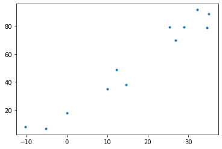

```python
plt.plot(temp,icecream,'.')
```

- 온도와 아이스크림판매량의 산점도

`-` 질병 = 30 + 온도 $\times$ 0.5 + $\epsilon^*$

```python
np.random.seed(2)
ϵ2=np.random.normal(size=12,scale=5)
disease= temp * 0.5 + 30 +ϵ2
```

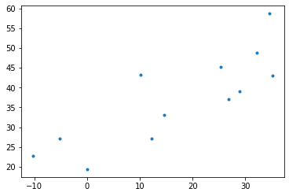

```python
plt.plot(temp,disease,'.')
```

- 온도와 소아마비의 산점도

`-` 아이스크림과 질병의 산점도를 그려보자.

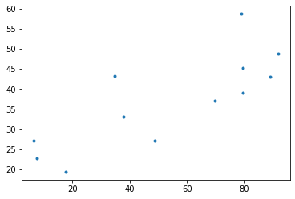

```python
plt.plot(icecream,disease,'.')
```

- 양의 상관관계에 있다.

`-` 아이스크림 중 어떠한 물질이 소아마비를 일으키는 것이 분명하므로 (인과성이 분명해보이니까) 아래와 같은 모형을 세우자. <-- 여기서부터 틀렸음

$${\tt disease}_i = \beta_0 + \beta_1 {\tt icecream}_i + \epsilon_i, \quad {\bf for} ~ i=1,2,\dots, 12 $$

`-` 적절한 $\beta_0$와 $\beta_1$을 추정하면 우리는 아이스크림과 소아마비의 관계를 알 수 있다. <-- 틀린주장

- 틀린모형
- 도데체 우리가 뭘 잘못했는가?

`-` 두 변수 사이의 상관관계가 있어도 원인이 다른변수에 숨겨진 경우가 있음.

- 예제의 논리로 치면 아이스크림과 익사자도 상관계수가 높을것임.
- 그렇다면 아이스림을 먹으면 물에 빠져죽을것이다? 라고 주장할 수 있나?
- 사실 기온이 숨겨진 원인이고 기온이 증가하면 아이스크림 판매량도 증가하고 폭염때문에 익사사고율도 높아지는 관계임

`-` 아래와 같은 예제를 생각하자.

- 인구수 $\to$ 교회
- 인구수 $\to$ 범죄건수
- 지역별 교회와 범죄건수를 살펴보면 상관관계가 높게 나올것임

`-` 교회를 지으면 범죄건수가 증가한다?

- 사실 그렇지 않을것임.
- 인구수가 비슷한 도시끼리 묶어서 비교해보면 교회수와 범죄건수는 상관없을것임!!

`-` 올바른분석: 온도가 비슷한 그룹끼리 묶어서 그려보자 $\to$ 상관계수가 줄어들 것이다.

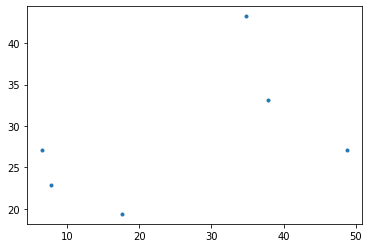

```python
plt.plot(icecream[:6],disease[:6],'.')
```

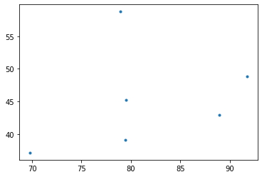

```python
plt.plot(icecream[6:],disease[6:],'.')
```

`-` 진짜로 선형관계가 약해졌다..?

### 좀 더 그럴듯한 자료

`-` 위의 toy example은 데이터가 너무 작아 억지스러움.

#### Data

`-` 기상청에서 온도데이터를 다운받자.

- 기상청 기후자료 $\to$ 오른쪽에 기상자료 개방 포털클릭 $\to$ 기온분석

```python
df= pd.read_csv('2021-10-18-extremum.csv')
```

`-` 데이터관찰

```python
df
```

|  | 지점번호 | 지점명 | 일시 | 평균기온(℃) | 최고기온(℃) | 최고기온시각 | 최저기온(℃) | 최저기온시각일교차 | Unnamed: 8 |
| --- | --- | --- | --- | --- | --- | --- | --- | --- | --- |
| 0 | 146 | 전주 | 2020-01-01 | -0.5 | 4.3 | 15:09 | -6.4 | 1:42 | 10.7 |
| 1 | 146 | 전주 | 2020-01-02 | 1.4 | 6.5 | 14:12 | -3.0 | 7:55 | 9.5 |
| 2 | 146 | 전주 | 2020-01-03 | 2.6 | 7.6 | 13:32 | -0.5 | 23:53 | 8.1 |
| 3 | 146 | 전주 | 2020-01-04 | 2.0 | 7.7 | 13:51 | -2.6 | 5:30 | 10.3 |
| 4 | 146 | 전주 | 2020-01-05 | 2.5 | 8.6 | 14:05 | -3.2 | 7:36 | 11.8 |
| ... | ... | ... | ... | ... | ... | ... | ... | ... | ... |
| 361 | 146 | 전주 | 2020-12-27 | 5.1 | 9.6 | 11:51 | 1.6 | 5:07 | 8.0 |
| 362 | 146 | 전주 | 2020-12-28 | 6.2 | 13.9 | 13:56 | 0.5 | 6:04 | 13.4 |
| 363 | 146 | 전주 | 2020-12-29 | 1.9 | 6.3 | 14:01 | -1.7 | 23:54 | 8.0 |
| 364 | 146 | 전주 | 2020-12-30 | -6.5 | -1.6 | 0:01 | -8.6 | 21:37 | 7.0 |
| 365 | 146 | 전주 | 2020-12-31 | -5.3 | -1.2 | 16:29 | -10.0 | 3:36 | 8.8 |

366 rows × 9 columns

`-` 평균기온만 뽑아내자.

```python
pd.Series(df.columns)
```

```
0          지점번호
1           지점명
2            일시
3       평균기온(℃)
4       최고기온(℃)
5        최고기온시각
6       최저기온(℃)
7     최저기온시각일교차
8    Unnamed: 8
dtype: object
```

```python
temp=np.array(df.iloc[:,3])
```

```python
temp
```

```
array([-0.5,  1.4,  2.6,  2. ,  2.5,  5.9, 12.4,  4.4,  2. ,  0.9,  2.5,
        2.3,  1.2,  1.4,  0.4,  0.4,  1. ,  0.7,  3.2,  3.5,  1.5,  3.5,
        6.3,  4.9,  4.9,  7.1,  6.1,  6.8,  6.7,  5.1,  4.2,  3.6,  2.5,
        1.5,  0.7, -3.7, -4.1, -0.3,  2. ,  0.3,  5. ,  8.4,  9.5,  7.4,
        8.9, 10.6,  0.9, -3. , -1.3,  2.9,  5.9,  9.2,  6.1,  3.7,  8.8,
        8.5,  8.1,  6.5,  6. ,  7.7,  5.6,  4.9,  6.8,  3.8,  2.6,  4.5,
        7. ,  9.1,  9.4,  6.4,  4.6,  7. ,  6.4,  5. ,  6. ,  4.5,  8.3,
       12.1, 10.3,  9.7, 15. , 13.4,  9.3, 10.2, 14.7, 15.2,  9.9,  7.2,
        8.1, 10.8, 11.2,  9.8,  9.4,  9.6,  8. ,  6.3,  8.4, 10.6,  9.6,
        8.4,  9.9,  8.4,  8.7,  9.8, 11.9, 12. , 16. , 14.2, 11.5, 11.2,
       10.8,  8.7,  7.6,  9.1, 10.7, 14.7, 13.1, 11.9, 12.8, 15.1, 18.9,
       23. , 21.5, 19.6, 17.9, 14.7, 20.5, 20.7, 18.6, 17.4, 14.3, 17.8,
       16. , 16.1, 21.5, 18.1, 17. , 20.1, 19.4, 13.9, 15.4, 17.8, 19.7,
       20.6, 18.3, 16.5, 17.9, 18.4, 18.3, 21.1, 22.8, 20.9, 19.5, 20. ,
       23.3, 24.5, 24. , 23.2, 23.3, 25.7, 27.3, 26. , 25.1, 23.8, 24.5,
       22.9, 22.4, 22.8, 22.3, 19.8, 22.9, 22.9, 24.5, 25.4, 26. , 23.7,
       22.3, 22.8, 24.8, 23.5, 22. , 20.2, 21.1, 23. , 21.2, 19.9, 22.9,
       23.1, 23.9, 24.1, 26.2, 25.7, 25.1, 22.3, 21.2, 20.3, 20.6, 23.5,
       24.1, 24.4, 27.1, 24.3, 24.9, 22.1, 22.4, 21.7, 23.2, 23.6, 23.9,
       25.1, 24.9, 25.7, 26.3, 26.3, 28. , 28.4, 29.1, 27.9, 26.1, 23.8,
       24.2, 27.4, 26.5, 26.7, 28.2, 29.1, 29.1, 29. , 28.7, 28.3, 28.5,
       27.9, 27.8, 28. , 26.5, 27.6, 28.6, 30. , 28.7, 29.6, 27.9, 27. ,
       27.6, 26.9, 27.3, 24.9, 23.2, 24.1, 22.7, 20.8, 19.5, 23.8, 22.2,
       23.3, 21.2, 20.7, 21.3, 22. , 23. , 22.2, 21.9, 20.5, 20. , 19.8,
       18.6, 19.2, 19.5, 21.1, 20.3, 20.1, 19.9, 19.6, 18.4, 19.1, 19.9,
       20.6, 20. , 18. , 14.6, 14.9, 16.8, 17.1, 17.3, 17.9, 18.2, 17.2,
       13.7, 13.6, 12.9, 12.4, 13.5, 13.6, 14.3, 14.8, 14.5, 13.4, 10.7,
       10.4, 12.4, 12.7, 13.7, 14.3, 11.2, 11.8, 14.1, 12.4, 12.5,  7.5,
        6.3,  9.5, 13.5, 13.7,  9.6,  7.5,  9.2,  9.5, 10.8, 10.8, 12.1,
       12.8, 12.8, 15.8, 20.2, 16.4,  7.5,  7.9,  8.1,  4.8,  5.7,  6.2,
        7.7,  6.3,  3.7,  3.4,  3.7,  2.7,  3.9,  2.4,  1.3,  3.8,  4.2,
        4.7,  2.1,  2.5,  5.9,  6.6,  5.1,  3.1, -3.4, -4.4, -4. , -2.4,
        0.9, -2.7, -0.9,  1.7,  2.9,  5.4,  4.7,  1.5,  3.4,  5.1,  6.2,
        1.9, -6.5, -5.3])
```

`-` 아이스크림 판매량

```python
np.random.seed(1)
ϵ1= np.random.normal(size=366, scale=10) ## 2020년 윤달이엇음 그래서 366
icecream = temp * 2 + 30 + ϵ1
```

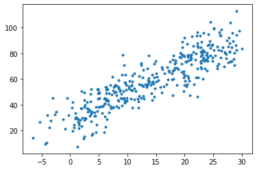

```python
plt.plot(temp,icecream,'.')
```

`-` 소아마비

```python
np.random.seed(2)
ϵ2=np.random.normal(size=366,scale=1)
disease= temp * 0.5 + 40 +ϵ2
```

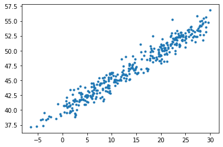

```python
plt.plot(temp,disease,'.')
```

`-` 아이스크림과 소아마비의 corr

```python
np.corrcoef(icecream,disease)
```

```
array([[1.        , 0.85852589],
       [0.85852589, 1.        ]])
```

`-` 여름만뽑아서 그려보자.

```python
temp>25
```

```
array([False, False, False, False, False, False, False, False, False,
       False, False, False, False, False, False, False, False, False,
       False, False, False, False, False, False, False, False, False,
       False, False, False, False, False, False, False, False, False,
       False, False, False, False, False, False, False, False, False,
       False, False, False, False, False, False, False, False, False,
       False, False, False, False, False, False, False, False, False,
       False, False, False, False, False, False, False, False, False,
       False, False, False, False, False, False, False, False, False,
       False, False, False, False, False, False, False, False, False,
       False, False, False, False, False, False, False, False, False,
       False, False, False, False, False, False, False, False, False,
       False, False, False, False, False, False, False, False, False,
       False, False, False, False, False, False, False, False, False,
       False, False, False, False, False, False, False, False, False,
       False, False, False, False, False, False, False, False, False,
       False, False, False, False, False, False, False, False, False,
       False, False, False, False, False, False,  True,  True,  True,
        True, False, False, False, False, False, False, False, False,
       False, False,  True,  True, False, False, False, False, False,
       False, False, False, False, False, False, False, False, False,
       False,  True,  True,  True, False, False, False, False, False,
       False, False,  True, False, False, False, False, False, False,
       False, False,  True, False,  True,  True,  True,  True,  True,
        True,  True,  True, False, False,  True,  True,  True,  True,
        True,  True,  True,  True,  True,  True,  True,  True,  True,
        True,  True,  True,  True,  True,  True,  True,  True,  True,
        True,  True, False, False, False, False, False, False, False,
       False, False, False, False, False, False, False, False, False,
       False, False, False, False, False, False, False, False, False,
       False, False, False, False, False, False, False, False, False,
       False, False, False, False, False, False, False, False, False,
       False, False, False, False, False, False, False, False, False,
       False, False, False, False, False, False, False, False, False,
       False, False, False, False, False, False, False, False, False,
       False, False, False, False, False, False, False, False, False,
       False, False, False, False, False, False, False, False, False,
       False, False, False, False, False, False, False, False, False,
       False, False, False, False, False, False, False, False, False,
       False, False, False, False, False, False, False, False, False,
       False, False, False, False, False, False])
```

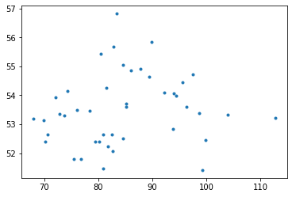

```python
plt.plot(icecream[temp>25],disease[temp>25],'.')
```

`-` 산점도

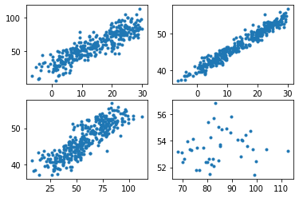

```python
fig, ((ax1,ax2),(ax3,ax4)) = plt.subplots(2,2)
ax1.plot(temp,icecream,'.')
ax2.plot(temp,disease,'.')
ax3.plot(icecream,disease,'.')
ax4.plot(icecream[temp>25],disease[temp>25],'.')
```

`-` 아래와 같이 그릴수도 있다.

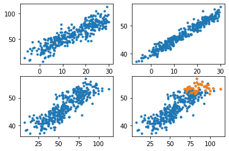

```python
fig, ((ax1,ax2),(ax3,ax4)) = plt.subplots(2,2)
ax1.plot(temp,icecream,'.')
ax2.plot(temp,disease,'.')
ax3.plot(icecream,disease,'.')
ax4.plot(icecream,disease,'.')
ax4.plot(icecream[temp>25],disease[temp>25],'.')
```

### 온도구간을 세분화 하여 시각화

`-` 목표: 모든 온도구간에 대하여 각각 색을 다르게 하여 그려보자.

- 사실 지금 변수는 온도, 아이스크림, 소아마비
- 지금까지는 기본산점도만 사용하였기에 2차원만 가능했음. $\to$ 그래서 각각의 산점도를 정신없이 그려왔던것임
- 온도가 유사한 지역을 색으로 묶으면 3차원이 가능함

`-` 일단 데이터 프레임을 정리하자.

```python
df1= pd.DataFrame({'temp':temp, 'icecream':icecream, 'disease':disease})
```

```python
df1
```

|  | temp | icecream | disease |
| --- | --- | --- | --- |
| 0 | -0.5 | 45.243454 | 39.333242 |
| 1 | 1.4 | 26.682436 | 40.643733 |
| 2 | 2.6 | 29.918282 | 39.163804 |
| 3 | 2.0 | 23.270314 | 42.640271 |
| 4 | 2.5 | 43.654076 | 39.456564 |
| ... | ... | ... | ... |
| 361 | 5.1 | 49.591687 | 41.304273 |
| 362 | 6.2 | 22.966766 | 42.932831 |
| 363 | 1.9 | 37.324944 | 40.373389 |
| 364 | -6.5 | 14.635630 | 37.166022 |
| 365 | -5.3 | 26.678135 | 37.292153 |

366 rows × 3 columns

`-` 온도를 카테고리화 하여보자. $\to$ 적당한 구간을 설정하기 위해 히스토그램을 그리자.

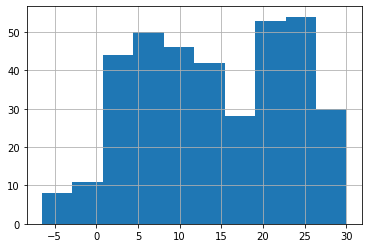

```python
df1.temp.hist() ## 방법1
```

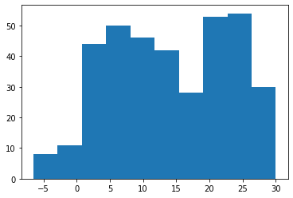

```python
plt.hist(df1.temp) ## 방법2
```

`-` 구간은 5정도로 정하면 될것 같다.

`-` 아래와 같은 구간설정

```python
def f(x):
    if x < 0:
        y='0'
    elif x<5:
        y='5'
    elif x<10:
        y='10'
    elif x<15:
        y='15'
    elif x<20:
        y='20'
    elif x<25:
        y='25'
    else:
        y='30'
    return y
```

`-` 새로운 열 추가

```python
df1['temp2']=list(map(f,df1.temp))
```

```python
df1
```

|  | temp | icecream | disease | temp2 |
| --- | --- | --- | --- | --- |
| 0 | -0.5 | 45.243454 | 39.333242 | 0 |
| 1 | 1.4 | 26.682436 | 40.643733 | 5 |
| 2 | 2.6 | 29.918282 | 39.163804 | 5 |
| 3 | 2.0 | 23.270314 | 42.640271 | 5 |
| 4 | 2.5 | 43.654076 | 39.456564 | 5 |
| ... | ... | ... | ... | ... |
| 361 | 5.1 | 49.591687 | 41.304273 | 10 |
| 362 | 6.2 | 22.966766 | 42.932831 | 10 |
| 363 | 1.9 | 37.324944 | 40.373389 | 5 |
| 364 | -6.5 | 14.635630 | 37.166022 | 0 |
| 365 | -5.3 | 26.678135 | 37.292153 | 0 |

366 rows × 4 columns

```python
from plotnine import *
```

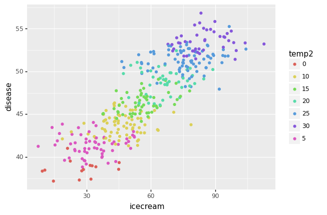

```python
ggplot(data=df1)+geom_point(aes(x='icecream', y='disease',color='temp2'))
```

`-` 온도 구간별로 추세선추가

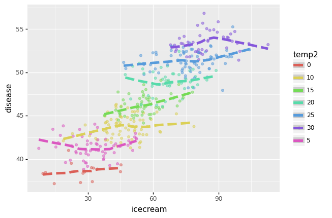

```python
ggplot(data=df1)+geom_point(aes(x='icecream', y='disease',color='temp2'),alpha=0.5)+geom_smooth(aes(x='icecream', y='disease',color='temp2'),size=2,linetype='dashed')
```

`-` 온도를 통제하니까 아이스크림과 질병은 관련이 없어보인다!

#### 관련있는경우라면?

```python
disease= temp * 0 + icecream*0.15 + 30 + ϵ2*2
```

```python
df2=pd.DataFrame({'temp':temp,'icecream':icecream,'disease':disease})
df2['temp2']=list(map(f,df2.temp))
```

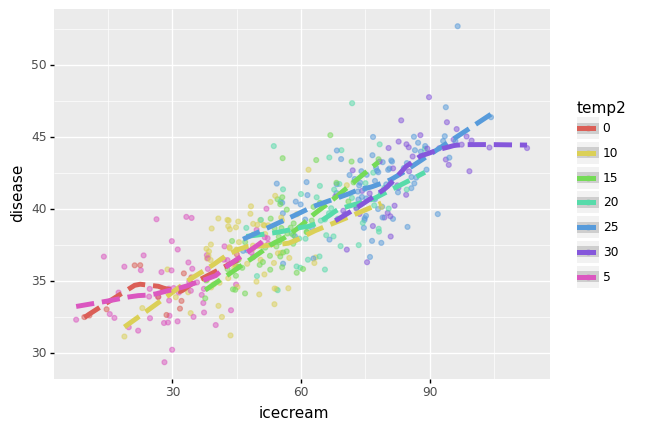

```python
ggplot(data=df2)+geom_point(aes(x='icecream', y='disease',color='temp2'),alpha=0.5)+geom_smooth(aes(x='icecream', y='disease',color='temp2'),size=2,linetype='dashed')
```

[figure not shown]

```python
ggplot(data=df)+geom_point(aes(x='icecream', y='disease'),alpha=0.5)
```

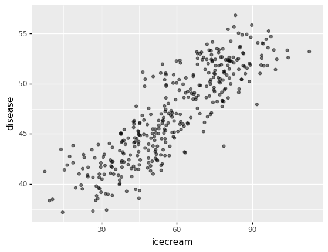

```python
ggplot(data=df1)+geom_point(aes(x='icecream', y='disease'),alpha=0.5)
```

```python
df1.corr()
```

|  | temp | icecream | disease |
| --- | --- | --- | --- |
| temp | 1.000000 | 0.886405 | 0.973543 |
| icecream | 0.886405 | 1.000000 | 0.858526 |
| disease | 0.973543 | 0.858526 | 1.000000 |

```python
df2.corr()
```

|  | temp | icecream | disease |
| --- | --- | --- | --- |
| temp | 1.000000 | 0.886405 | 0.737474 |
| icecream | 0.886405 | 1.000000 | 0.823604 |
| disease | 0.737474 | 0.823604 | 1.000000 |

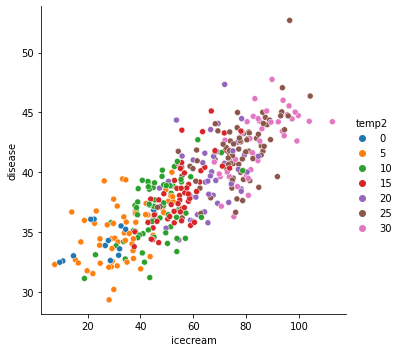

```python
import seaborn as sns
sns.relplot(data=df2,x='icecream',y='disease',hue='temp2')
```

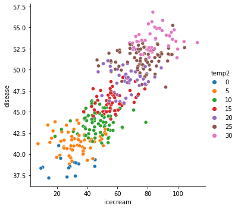

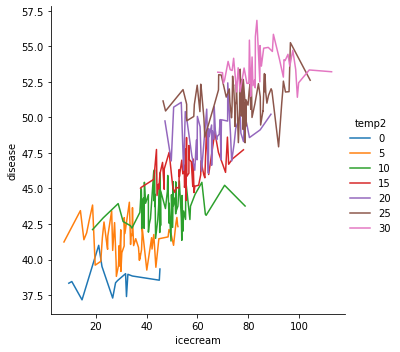

```python
import seaborn as sns
sns.relplot(data=df1,x='icecream',y='disease',hue='temp2')
sns.relplot(data=df1,x='icecream',y='disease',hue='temp2',kind='line')
```